```python
# Initialize Otter
import otter
grader = otter.Notebook("project_134.ipynb")
```

```python
import warnings
warnings.simplefilter(action='ignore', category=FutureWarning)
```

# Final Project

## PSTAT 134 (Winter 2024)

## Collaboration Policy

Data science is a collaborative activity. While you may talk with others about the homework, we ask that you **write your solutions individually**. If you do discuss the assignments with others please **include their names** at the top of your notebook.

**Collaborators**: *list collaborators here*

```python
%xmode Verbose
```

```
Exception reporting mode: Verbose
```

## Question 1: Using Linear Algebra for Optimization

In recommender system module, low-rank matrix factorization was used to execute latent factor modeling of movie ratings data.

Specifically, we calculated matrices $U$ and $V$ to solve the following optimization problem (if all ratings were given): $$ \begin{aligned} \min_{U,V} f(U,V) &= \min_{U,V} \|R - V U^T\|_F^2 =\min_{U,V} \left\{ \sum_{m=1}^M\sum_{i=1}^I D_{mi}(r_{mi} - v_m u_i^T)^2 \right\}, \end{aligned} $$ where $$ \begin{aligned} D_{mi} = \begin{cases} 1 \text{, if $r_{mi}$ is observed}\\ 0 \text{, if $r_{mi}$ is missing.}\\ \end{cases} \end{aligned} $$

The best $U$ and $V$ were calculated iteratively by improving on current estimates: $$ \begin{aligned} u_i^{\text{new}} &= u_i + 2\alpha D_{mi}(r_{mi} - v_m u_i^T)\cdot v_m\\ v_m^{\text{new}} &= v_m + 2\alpha D_{mi}(r_{mi} - v_m u_i^T)\cdot u_i, \end{aligned} $$ where $\alpha$ is the step-size that is to be chosen by the user, $i = 1,2,\ldots, I$, $m = 1,\ldots,M$. (We won't discuss the role of $\alpha$ in this class, but treat it as an arbitrary, but given, parameter)

We can make calculating the updates more efficient by calculating them with matrix operations. For example, instead of calculating each deviation $\gamma_{mi} = r_{mi} - v_m u_i^T$ separately for all $m=1,2,\dots,M$ and $i=1,2,\dots,I$, matrix $\Gamma$ of all deviations can be computed together using matrix operation *(verify for yourself)*: $$\Gamma = R - VU^T$$

Similarly, updating $U$ and $V$ can be combined into matrix calculations which makes the optimization procedure more efficient.

First, note that updates for $u_i$, $i=1,2,\dots,I$ can be rewritten as $$ \begin{aligned} u_1^{\text{new}} &= u_1 + 2\alpha D_{m1}\gamma_{m1}\cdot v_m\\ u_2^{\text{new}} &= u_2 + 2\alpha D_{m2}\gamma_{m2}\cdot v_m\\ \vdots\quad &\qquad\qquad\vdots\\ u_I^{\text{new}} &= u_I + 2\alpha D_{mI}\gamma_{mI}\cdot v_m. \end{aligned} $$ Stacking all $I$ equations into a matrix form, $$ \begin{aligned} U^{\text{new}} &= U + 2\alpha (D_{m-}\circ\Gamma_{m-})^T v_m, \end{aligned} $$ where $I_{m-}$ and $\Gamma_{m-}$ are the $m$-th row of $\Gamma$ and $D$ (use the notation $\Gamma_{-i}$ for the $i$-th column). Hadamard product (elementwise matrix product) is denoted with $\circ$. When evaluating $U^{\text{new}}$, the latest updated values of $U$, $V$, and $\Gamma$ are used.

Note that there are $M$ such update equations (one for each $m=1,2,\dots,M$) that can also be combined into one matrix update equation involving matrices $U$, $V$, $\Gamma$ and scalars. As stated earlier, since $\alpha$ is assumed to be an arbitrary step-size parameter, we can replace $\alpha/M$ with $\alpha$.

### Question 1a: Using Linear Algebra for Optimization

Complete the following update equations: $$ \begin{aligned} U^{\text{new}} &= U + 2\alpha[\text{some function of }\Gamma][\text{some function of }V]\\ V^{\text{new}} &= V + 2\alpha[\text{some function of }\Gamma][\text{some function of }U] \end{aligned} $$

**SOLUTION**

$$ \begin{aligned} U^{\text{new}} &= U + 2\alpha (D_{m-}\circ\Gamma_{m-})^T v_m, \end{aligned} $$

$$ \begin{aligned} V^{\text{new}} &= V + 2\alpha (D_{m} \circ \Gamma_{m}) U \end{aligned} $$

### Question 1b: Implementing Updates

In this problem, you will implement the updates calculated in the previous problem. Define the following three functions:

- `update_G(R, U, V)`: computes deviation $R-VU^T$
- `update_U(G, U, V, alpha=0.01)`: calculates update $U^{\text{new}}$
- `update_V(G, U, V, alpha=0.01)`: calculates update $V^{\text{new}}$

Each function should only be one line of matrix operations. Three functions is to be applied sequentially, using the most up-to-date estimates of $G$, $U$, and $V$.

Since some elements of `R` are `np.nan` for any missing ratings, `update_U` and `update_V` functions need to be adjusted by using `numpy.nan_to_num` function where appropriate. The function `numpy.nan_to_num` will let you replace `NaN` to some number, so that missing ratings do not interfere with updates.

```python
import numpy as np
import pandas as pd

def update_G(R, U, V):
    return R - np.dot(V, U.T)

def update_U(G, U, V, alpha=0.01):
    # Compute the update for U. The Dm mask is the same as G but with binary values.
    Dm = (~np.isnan(G)).astype(int)
    return U + 2 * alpha * np.dot((np.nan_to_num(G) * Dm).T, V)


def update_V(G, U, V, alpha=0.01):
    # Compute the update for V. The Dm mask is the same as G but with binary values.
    Dm = (~np.isnan(G)).astype(int)
    return V + 2 * alpha * np.dot(np.nan_to_num(G) * Dm, U)



# small test to help debug (keep intact)
np.random.seed(1)

M_ = 5
I_ = 3
K_ = 2

R_ = np.random.rand(M_, I_).round(1)
R_[0, 0] = R_[3, 2] = np.nan
U_ = np.random.rand(I_, K_).round(1)
V_ = np.random.rand(M_, K_).round(1)
G_ = update_G(R_, U_, V_)
```

```python
grader.check("q1b")
```

```
q1b
```

passed! 🎉

### Question 1c: Construct Optimization Algorithm

Combine the above functions to implement the optimization algorithm to iteratively compute $U$ and $V$.

But, first, here are functions that will calculate RMSE and quantify the maximum update (in absolute value) made by `update_U` and `update_V` after they are called.

```python
def rmse(X):
    """
    Computes root-mean-square-error, ignoring nan values
    """
    return np.sqrt(np.nanmean(X**2))

def max_update(X, Y, relative=True):
    """
    Compute elementwise maximum update

    parameters:
    - X, Y: numpy arrays or vectors
    - relative: [True] compute relative magnitudes

    returns
    - maximum difference between X and Y (relative to Y)

    """
    if relative:
        updates = np.nan_to_num((X - Y)/Y)
    else:
        updates = np.nan_to_num(X - Y)

    return np.linalg.norm(updates.ravel(), np.inf)
```

A template for the optimization algorithm is given below. Fill-in the missing portions to complete the algorithm.

```python
def compute_UV(Rdf, K=5, alpha=0.01, max_iteration=5000, diff_thr=1e-3):

    R = Rdf.values
    Rone = pd.DataFrame().reindex_like(Rdf).replace(np.nan, 1) # keep data frame metadata

    M, I = R.shape            # number of movies and users
    U = np.random.rand(I, K)  # initialize with random numbers
    V = np.random.rand(M, K)  # initialize with random numbers
    G = update_G(R, U, V)     # calculate residual

    track_rmse = []
    track_update = []
    for i in range(0, max_iteration):

        Unew = update_U(G, U, V, alpha)
        Gnew = update_G(R, Unew, V)

        Vnew = update_V(Gnew, Unew, V, alpha)
        Gnew = update_G(R, Unew, Vnew)

        track_rmse.append({
            'iteration': i,
            'rmse': rmse(Gnew),
            'max residual change': max_update(Gnew, G, relative=False)
        })
        track_update.append({
            'iteration': i,
            'max update': max(max_update(Unew, U), max_update(Vnew, V))
        })

        U = Unew
        V = Vnew
        G = Gnew

        if track_update[-1]['max update'] < diff_thr:
            break

    kindex = pd.RangeIndex(start=0, stop=K, step=1, name='k')
    U = pd.DataFrame(U, index=Rdf.columns, columns=kindex)
    V = pd.DataFrame(V, index=Rdf.index, columns=kindex)

    return {
        'U': U,
        'V': V,
        'rmse': pd.DataFrame(track_rmse),
        'update': pd.DataFrame(track_update)
    }

Rsmall = pd.read_pickle('data/ratings_stacked_small.pkl').unstack()

np.random.seed(134) # set seed for tests
output1 = compute_UV(Rsmall, K=10, alpha=0.001)
```

```python
grader.check("q1c")
```

```
q1c
```

passed! 🙌

Running the function on a different sized problem to check if `compute_UV` adapts to changing problem sizes. There is nothing new to do here

```python
# These tests should pass if `compute_UV` works properly
np.random.seed(134) # set seed for tests
output2 = compute_UV(Rsmall.iloc[:7, :5], K=8)
```

```python
## TEST ##
output2['U'].shape
```

```
(5, 8)
```

```python
## TEST ##
print((output2['V']@output2['U'].T).round(2))
```

```
                                   rating
user id                               1     85    269   271   301
movie id movie title
132      Wizard of Oz, The (1939)    4.00  5.00  5.00  5.00  4.01
238      Raising Arizona (1987)      4.00  2.00  5.00  4.00  3.01
748      Saint, The (1997)           1.92  1.53  1.97  1.47  1.52
196      Dead Poets Society (1989)   5.00  4.00  1.00  4.00  4.00
197      Graduate, The (1967)        5.00  5.00  5.00  4.00  5.01
185      Psycho (1960)               4.00  3.67  5.00  3.00  3.80
194      Sting, The (1973)           4.01  4.01  5.00  5.00  3.99
```

```python
## TEST ##
output2['V'].shape
```

```
(7, 8)
```

```python
## TEST ##
output2['U'].index
```

```
MultiIndex([('rating',   1),
            ('rating',  85),
            ('rating', 269),
            ('rating', 271),
            ('rating', 301)],
           names=[None, 'user id'])
```

```python
## TEST ##
output2['V'].index
```

```
MultiIndex([(132,  'Wizard of Oz, The (1939)'),
            (238,    'Raising Arizona (1987)'),
            (748,         'Saint, The (1997)'),
            (196, 'Dead Poets Society (1989)'),
            (197,      'Graduate, The (1967)'),
            (185,             'Psycho (1960)'),
            (194,         'Sting, The (1973)')],
           names=['movie id', 'movie title'])
```

```python
## TEST ##
output2['U'].columns
```

```
RangeIndex(start=0, stop=8, step=1, name='k')
```

```python
## TEST ##
output2['V'].columns
```

```
RangeIndex(start=0, stop=8, step=1, name='k')
```

### Question 1d: Interpret Diagnostic Plots

Following figures tell us if the optimization algorithm is working properly.

```python
import altair as alt
logscale = alt.Scale(type='log', base=10)
fig_rmse = \
    alt.Chart(output1['rmse'])\
    .mark_line()\
    .encode(
        x='iteration:Q',
        y=alt.Y('rmse:Q', scale=logscale)
    )
fig_max_residual_change = \
    alt.Chart(output1['rmse'])\
    .mark_line()\
    .encode(
        x='iteration:Q',
        y=alt.Y('max residual change:Q', scale=logscale)
    )
fig_updates = \
    alt.Chart(output1['update'])\
    .mark_line()\
    .encode(
        x='iteration:Q',
        y=alt.Y('max update:Q', scale=logscale)
    )
alt.vconcat(
    fig_rmse | fig_max_residual_change,
    fig_updates
)
```

[interactive chart not shown]

By referring back to the function used to calculate the quantities in each figure, describe what each figure is showing and interpret the behavior of the optimization algorithm.

**SOLUTION**

RMSE (Root Mean Square Error) Plot: This figure displays the RMSE of the residual matrix $\Gamma$ (the difference between the actual ratings matrix $R$ and the predicted ratings from the current $U$ and $V$ matrices) for each iteration. The RMSE is a measure of the accuracy of the reconstructed matrix $UV^T$ to the original matrix $R$, where a lower RMSE indicates better accuracy. In the plot, the RMSE rapidly decreases in the initial iterations, indicating that the model quickly improves its predictive accuracy. The gradual flattening of the curve suggests that gains in accuracy diminish with each iteration as the model approaches an optimal solution.  
Max Residual Change Plot: This plot shows the maximum absolute change in the residual matrix $\Gamma$ between consecutive iterations. This metric indicates how much the prediction error changes from one iteration to the next. As the optimization progresses, this value should decrease, reflecting the stabilization of the algorithm as it converges to a solution. The downward trend indicates that the optimization is making smaller adjustments to $U$ and $V$ over time, suggesting convergence.  
Max Update Plot: This graph represents the maximum change made to the elements of $U$ and $V$ matrices during each update, relative to their values from the previous iteration. The 'max update' value being plotted on a logarithmic scale shows how much the matrices $U$ and $V$ change in each iteration. The spikes in the plot could be due to the learning rate or the nature of the gradient descent updates where certain iterations may lead to larger changes in the matrix elements. The overall downward trend indicates that over time the changes to $U$ and $V$ are getting smaller, which is expected as the optimization algorithm converges. However, the occasional spikes suggest some instability or periodic large updates, which might require investigating the learning rate, the initialization, or other aspects of the optimization process to ensure smooth convergence.

### Question 1e: Analyze Large Dataset

Following code will analyze a larger dataset:

```python
# run on larger dataset
Rbig = pd.read_pickle('data/ratings_stacked.pkl').unstack()[100:]

np.random.seed(134) # set seed for tests
output3 = compute_UV(Rbig, K=5, alpha=0.001, max_iteration=500)

Rhatbig = output3['V']@output3['U'].T
```

```python
fit_vs_obs = pd.concat([
    Rhatbig.rename(columns={'rating':'fit'}),
    Rbig.rename(columns={'rating':'observed'}),
], axis=1).stack().dropna().reset_index()[['fit','observed']]

fit_vs_obs = fit_vs_obs.iloc[np.random.choice(len(fit_vs_obs), 5000)]

alt.Chart(fit_vs_obs).transform_density(
    density='fit',
    bandwidth=0.01,
    groupby=['observed'],
    extent= [0, 6]
).mark_bar().encode(
    alt.X('value:Q'),
    alt.Y('density:Q'),
    alt.Row('observed:N')
).properties(width=800, height=50)
```

[interactive chart not shown]

**Question**: Consider the above plot.

- By reading the code, comment on what the plot is illustrating.
- What happens when you add `counts=True` to `transform_density`? What can you conclude?

**SOLUTION**

The density plot is arranged as a series of horizontal bar charts, one for each observed rating. The x-axis represents the predicted rating value, and the y-axis represents the density (the smooth approximation of the distribution). The plot is set to show how the predicted ratings are distributed around each actual rating value.  
Adding counts=True to transform_density changes the calculation from a probability density (which integrates to 1 over the space of possible values) to a count-based density (which sums to the number of data points). With counts=True, the y-axis of the plot would represent the count of data points that fall within each bin of the predicted rating values, rather than the probability density.

### Question 1f: Make Recommendation

What movies would you recommend to `user id` 601? Do you see any similarities to movies the user rated high?

```python
print((output3['V']@output3['U'].T['rating'][601]).round(2).sort_values(ascending=False).head())
```

```
movie id  movie title
172       Empire Strikes Back, The (1980)           9.96
204       Back to the Future (1985)                 7.91
1500      Santa with Muscles (1996)                 4.93
168       Monty Python and the Holy Grail (1974)    4.22
1467      Saint of Fort Washington, The (1993)      4.02
dtype: float64
```

```python
print(Rbig['rating'][601].round(2).sort_values(ascending=False).head())
```

```
movie id  movie title
168       Monty Python and the Holy Grail (1974)    5.0
132       Wizard of Oz, The (1939)                  5.0
173       Princess Bride, The (1987)                5.0
228       Star Trek: The Wrath of Khan (1982)       5.0
179       Clockwork Orange, A (1971)                5.0
Name: 601, dtype: float64
```

**SOLUTION**

Based on the predicted ratings for user id 601, the top recommendations are:

1. **Empire Strikes Back, The (1980)** with a predicted rating of 9.96.
2. **Back to the Future (1985)** with a predicted rating of 7.91.
3. **Santa with Muscles (1996)** with a predicted rating of 4.93.
4. **Monty Python and the Holy Grail (1974)** with a predicted rating of 4.22.
5. **Saint of Fort Washington, The (1993)** with a predicted rating of 4.02.

Looking at the movies that user 601 rated highly, we have:

1. **Monty Python and the Holy Grail (1974)**
2. **Wizard of Oz, The (1939)**
3. **Princess Bride, The (1987)**
4. **Star Trek: The Wrath of Khan (1982)**
5. **Clockwork Orange, A (1971)**

## Question 2: Regularization

One of the common problems in machine learning is overfitting, and a common method that remedies overfitting is regularization.

Recall that we solved the following optimization problem $$ \begin{aligned} \min_{U,V} f(U,V) &= \min_{U,V} \|R - V U^T\|_F^2 =\min_{U,V} \left\{ \sum_{m=1}^M\sum_{i=1}^I D_{mi}(r_{mi} - v_m u_i^T)^2 \right\}, \end{aligned} $$ where $$ \begin{aligned} D_{mi} = \begin{cases} 1 \text{, if $r_{mi}$ is observed}\\ 0 \text{, if $r_{mi}$ is missing.}\\ \end{cases} \end{aligned} $$

To prevent overfitting, we can introduce $L_2$ regularization on both the user matrix and the movie matrix. Then the new optimization problem is

$$ \begin{aligned} \min_{U,V} g(U,V) &=\min_{U,V} \|R - V U^T \|_F^2 + \lambda(\|U\|_F^2 + \|V\|_F^2)\\ &= \min_{U,V} \left\{ \sum_{m=1}^M\sum_{i=1}^I D_{mi}(r_{mi} - v_m u_i^T)^2 + \lambda (\sum_{i=1}^{I}\|u_i\|_2^2 + \sum_{m=1}^{M}\|v_m\|_2^2) \right\}\\ \end{aligned} $$ where $\lambda$ is a tuning parameter that determines the strength of regularization.

### Question 2a: Derive New Gradients and Update Rules

Based on the new objective function $g(U,V)$, derive its gradients and update rules for $U^{\text{new}}$ and $V^{\text{new}}$.

$ g(U, V) = \min_{U,V} \left \| R - VU^T \right \|_F^2 + \lambda(\left \| U \right \|_F^2 + \left \| V \right \|_F^2) $

To derive the gradients with respect to $ U $ and $ V $, let's denote the original cost function (without regularization) as $ f(U,V) $ and the regularization terms as $ R(U,V) $:

$ f(U,V) = \left \| R - VU^T \right \|_F^2 $  
$ R(U,V) = \lambda(\left \| U \right \|_F^2 + \left \| V \right \|_F^2) $

Then the gradient of $ g(U, V) $ with respect to $ U $ is:

$ \frac{\partial g}{\partial U} = \frac{\partial f}{\partial U} + \lambda \frac{\partial (\left \| U \right \|_F^2)}{\partial U} $

And the gradient of $ g(U, V) $ with respect to $ V $ is:

$ \frac{\partial g}{\partial V} = \frac{\partial f}{\partial V} + \lambda \frac{\partial (\left \| V \right \|_F^2)}{\partial V} $

From the original optimization problem without regularization, we have:

$ \frac{\partial f}{\partial U} = 2(V^T(VU^T - R)) $  
$ \frac{\partial f}{\partial V} = 2(U(VU^T - R)^T) $

Considering the L2 norm of $ U $ and $ V $, the gradients of the regularization terms are:

$ \frac{\partial (\left \| U \right \|_F^2)}{\partial U} = 2U $  
$ \frac{\partial (\left \| V \right \|_F^2)}{\partial V} = 2V $

So the gradients of $ g(U, V) $ with respect to $ U $ and $ V $ are:

$ \frac{\partial g}{\partial U} = 2(V^T(VU^T - R)) + 2\lambda U $  
$ \frac{\partial g}{\partial V} = 2(U(VU^T - R)^T) + 2\lambda V $

The update rules for $ U_{new} $ and $ V_{new} $ using gradient descent would be:

$ U_{new} = U - \alpha \left( \frac{\partial g}{\partial U} \right) $  
$ V_{new} = V - \alpha \left( \frac{\partial g}{\partial V} \right) $

Plugging in the expressions for the gradients:

$ U_{new} = U - \alpha (2V^T(VU^T - R) + 2\lambda U) $  
$ V_{new} = V - \alpha (2U(VU^T - R)^T + 2\lambda V) $

To write it in a simplified update rule form:

$ U_{new} = U - 2\alpha (V^T(VU^T - R) + \lambda U) $  
$ V_{new} = V - 2\alpha (U(VU^T - R)^T + \lambda V) $

### Question 2b: Implementing Updates

Implement new update functions similarly as in q1b.

```python
import numpy as np
import pandas as pd

def update_G_reg(R, U, V):
    """
    Computes the deviation matrix G, which is the difference between the observed ratings R
    and the predicted ratings from the current estimates of U and V matrices, handling NaN values.
    """
    return R - np.dot(V, U.T)

def update_U_reg(G, U, V, lam, alpha=0.01):
    """
    Update U matrix with regularization.
    """
    grad_U = -2 * (np.dot(V.T, np.nan_to_num(G)).T - lam * U)

    U_new = U - alpha * grad_U

    return U_new

def update_V_reg(G, U, V, lam, alpha=0.01):
    """
    Update V matrix with regularization.
    """
    grad_V = -2 * np.dot(np.nan_to_num(G), U) + 2 * lam * V

    # Update V using gradient descent step
    V_new = V - alpha * grad_V
    return V_new

# small test to help debug (keep intact)
np.random.seed(1)

M_ = 5
I_ = 3
K_ = 2
lam = 5.0

R_ = np.random.rand(M_, I_).round(1)
R_[0, 0] = R_[3, 2] = np.nan
U_ = np.random.rand(I_, K_).round(1)
V_ = np.random.rand(M_, K_).round(1)
G_ = update_G_reg(R_, U_, V_)
```

```python
grader.check("q2b")
```

```
q2b
```

passed! 🍀

### Question 2c: Construct Optimization Algorithm

Combine the above functions to implement the optimization algorithm to iteratively compute $U$ and $V$.

```python
def compute_UV_reg(Rdf, K=5, lam=0.5, alpha=0.01, max_iteration=5000, diff_thr=1e-3):

    R = Rdf.values
    Rone = pd.DataFrame().reindex_like(Rdf).replace(np.nan, 1) # keep data frame metadata

    M, I = R.shape            # number of movies and users
    U = np.random.rand(I, K)  # initialize with random numbers
    V = np.random.rand(M, K)  # initialize with random numbers
    G = update_G(R, U, V)     # calculate residual

    track_rmse = []
    track_update = []
    for i in range(0, max_iteration):

        Unew = update_U_reg(G, U, V, lam, alpha)
        Gnew = update_G_reg(R, Unew, V)

        Vnew = update_V_reg(Gnew, Unew, V, lam, alpha)
        Gnew = update_G_reg(R, Unew, Vnew)

        track_rmse += [{
            'iteration':i,
            'rmse': rmse(Gnew),
            'max residual change': max_update(Gnew, G, relative=False)
        }]
        track_update += [{
            'iteration':i,
            'max update':max(max_update(Unew, U), max_update(Vnew, V))
        }]

        U = Unew
        V = Vnew
        G = Gnew

        if track_update[-1]['max update'] < diff_thr:
            break

    track_rmse = pd.DataFrame(track_rmse)
    track_update = pd.DataFrame(track_update)

    kindex = pd.Index(range(0, K), name='k')
    U = pd.DataFrame(U, index=Rdf.columns, columns=kindex)
    V = pd.DataFrame(V, index=Rdf.index, columns=kindex)

    return {
        'U':U, 'V':V,
        'rmse': track_rmse,
        'update': track_update
    }

Rsmall = pd.read_pickle('data/ratings_stacked_small.pkl').unstack()

np.random.seed(134) # set seed for tests
output4 = compute_UV_reg(Rsmall, K=10, lam=0.5, alpha=0.001)


Rsmall = pd.read_pickle('data/ratings_stacked_small.pkl').unstack()

np.random.seed(134) # set seed for tests
output4 = compute_UV_reg(Rsmall, K=10, lam=0.5, alpha=0.001)
```

```python
grader.check("q2c")
```

```
q2c
```

passed! 🌟

### Question 2d: Investigating the Effects of Regularization

Adding the regularization terms to the objective function will affect the estimates of $U$ and $V$. Here, we consider comparing the user matrix $U$.

Using the dataset *Rsmall*, obtain two estimated user matrices, say $\hat{U}$ for a non-regularized model and $\hat{U}_{\text{reg}}$ for a regularized model. Select $K = 20$ and $\lambda = 5$. Come up with an effective visualization for comparing $\hat{U}$ and $\hat{U}_{\text{reg}}$, and describe any differences you notice. Additionally, analyze whether the observed differences in patterns align with the concept of regularization.

Provide reasoning supported by evidence, such as code implementation and results.

**SOLUTION**

```python
np.random.seed(134) # set seed for tests
output_noreg = compute_UV(Rsmall, K=20, alpha=0.001)
output_reg = compute_UV_reg(Rsmall, K=20, lam=5.0, alpha=0.001)
```

```python
Rhat_noreg = output_noreg['V'] @ output_noreg['U'].T
Rhat_reg = output_reg['V'] @ output_reg['U'].T
error_noreg = (Rsmall - Rhat_noreg).stack().dropna()
error_reg = (Rsmall - Rhat_reg).stack().dropna()
```

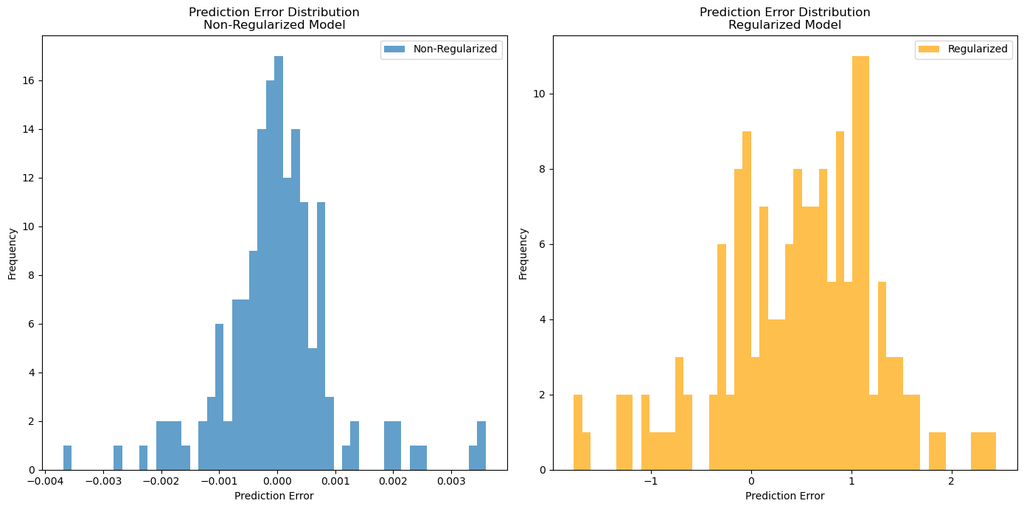

```python
import matplotlib.pyplot as plt

# Plot histograms of errors for both models
plt.figure(figsize=(14, 7))

# Histogram for non-regularized model
plt.subplot(1, 2, 1)
plt.hist(error_noreg, bins=50, alpha=0.7, label='Non-Regularized')
plt.xlabel('Prediction Error')
plt.ylabel('Frequency')
plt.title('Prediction Error Distribution\nNon-Regularized Model')
#plt.axvline(error_noreg.mean(), color='k', linestyle='dashed', linewidth=1)
plt.legend()

# Histogram for regularized model
plt.subplot(1, 2, 2)
plt.hist(error_reg, bins=50, alpha=0.7, color='orange', label='Regularized')
plt.xlabel('Prediction Error')
plt.ylabel('Frequency')
plt.title('Prediction Error Distribution\nRegularized Model')
#plt.axvline(error_reg.mean(), color='k', linestyle='dashed', linewidth=1)
plt.legend()
plt.tight_layout()
plt.show()
```

### Analysis in the Context of Regularization:

- Regularization is intended to prevent overfitting by penalizing larger weights in the model, leading to a simpler model that may not fit the training data as closely but should generalize better to unseen data.
- The narrower error distribution for the non-regularized model indicates that it may be fitting the training data more closely, potentially at the risk of overfitting.
- The wider error distribution for the regularized model suggests that it's more conservative with its predictions. The presence of larger errors may be a result of the regularization term shrinking the weights, thus leading to underfitting on the training data, but potentially better performance on unseen data.
- The differences in error distributions align with the concept of regularization. The regularized model sacrifices some accuracy on the training data to potentially achieve better generalization. This trade-off is a key aspect of regularization's role in machine learning.

The key takeaway is that while the non-regularized model might perform better on the training set, as evidenced by the high frequency of near-zero errors, the regularized model is likely more robust and could potentially perform better on new, unseen data, despite its apparently larger average error on the training set. This is because the regularization discourages complex models that fit the noise in the training data, promoting models that capture the underlying signal, which is what generalizes to new data.

### Question 2e: Practical Aspects

In the previous question, a specific values for $K$ and $\lambda$ were provided. Now, try applying various $K$'s and $\lambda$'s. Specifically, try the following:

- While keeping $K$ constant, experiment with different values of $\lambda$. What do you notice? Why do you think this happens?
- While keeping $\lambda$ constant, experiment with different values of $K$. What do you notice? Why do you think this happens?

If your optimization algorithm is correctly implemented, you will notice that the choice of $K$ and $\lambda$ has a significant impact on the final estimates. Hence, selecting appropriate values for $K$ and $\lambda$ is crucial when applying the recommendation algorithm in practice. As a practitioner, how would you approach choosing $K$ and $\lambda$?

Provide reasoning supported **by evidence**, such as code implementation and results.

**SOLUTION**

```python
# Define K values and lambda values you want to test
K_values = [5, 10, 20, 30]
lambda_values = [0.0001, 0.01, 0.1, 1]

# Initialize a dictionary to store MAEs
maes_noreg = {}
maes_reg = {}


# Loop over all K and lambda values
for K in K_values:
    for lam in lambda_values:
        # Set random seed for reproducibility
        np.random.seed(134)

        # Compute non-regularized matrix factorization
        output_noreg = compute_UV(Rsmall, K=K, alpha=0.001)
        output_reg = compute_UV_reg(Rsmall, K=K, lam=lam, alpha=0.001)

        Rhat_noreg = output_noreg['V'] @ output_noreg['U'].T
        Rhat_reg = output_reg['V'] @ output_reg['U'].T

        error_noreg = (Rsmall - Rhat_noreg).stack().dropna()
        mae_noreg = np.abs(error_noreg).mean()
        maes_noreg[(K, lam)] = mae_noreg

        # Compute regularized matrix factorization

        error_reg = (Rsmall - Rhat_reg).stack().dropna()
        mae_reg = np.abs(error_reg).mean()
        maes_reg[(K, lam)] = mae_reg

        # Output the MAE results
        #print(f'K={K}, lam={lam}, Non-regularized MAE={mae_noreg}, Regularized MAE={mae_reg}')

# Output the MAE dictionaries
print("Non-regularized MAEs:", maes_noreg)
print("Regularized MAEs:", maes_reg)
```

```
Non-regularized MAEs: {(5, 0.0001): rating    0.138439
dtype: float64, (5, 0.01): rating    0.138439
dtype: float64, (5, 0.1): rating    0.138439
dtype: float64, (5, 1): rating    0.138439
dtype: float64, (10, 0.0001): rating    0.007145
dtype: float64, (10, 0.01): rating    0.007145
dtype: float64, (10, 0.1): rating    0.007145
dtype: float64, (10, 1): rating    0.007145
dtype: float64, (20, 0.0001): rating    0.000662
dtype: float64, (20, 0.01): rating    0.000662
dtype: float64, (20, 0.1): rating    0.000662
dtype: float64, (20, 1): rating    0.000662
dtype: float64, (30, 0.0001): rating    0.000161
dtype: float64, (30, 0.01): rating    0.000161
dtype: float64, (30, 0.1): rating    0.000161
dtype: float64, (30, 1): rating    0.000161
dtype: float64}
Regularized MAEs: {(5, 0.0001): rating    0.177006
dtype: float64, (5, 0.01): rating    0.176991
dtype: float64, (5, 0.1): rating    0.181408
dtype: float64, (5, 1): rating    0.269125
dtype: float64, (10, 0.0001): rating    0.011932
dtype: float64, (10, 0.01): rating    0.01116
dtype: float64, (10, 0.1): rating    0.031169
dtype: float64, (10, 1): rating    0.210474
dtype: float64, (20, 0.0001): rating    0.001711
dtype: float64, (20, 0.01): rating    0.002096
dtype: float64, (20, 0.1): rating    0.022125
dtype: float64, (20, 1): rating    0.20992
dtype: float64, (30, 0.0001): rating    0.00026
dtype: float64, (30, 0.01): rating    0.0019
dtype: float64, (30, 0.1): rating    0.021534
dtype: float64, (30, 1): rating    0.209993
dtype: float64}
```

**Choosing $ K $ and $ \lambda $**: Choosing the right $ K $ and $ \lambda $ is about balancing complexity with generalization:

- **$ K = 30 $**
- **$ \lambda = 0.0001$**
- This model has the lowest mean average error of all regularized models (0.00026), indicating it performs the best.

```python
model = compute_UV_reg(Rsmall, K=30, lam=0.0001, alpha=0.001)
```

## Question 3: Segmentation in Latent Factor Space

Now that we have user matrix $U$ and movie matrix $V$, suppose we want to use the newly learned representation for an advertising campaign.

Suppose you are leading the planning of an online advertising campaign and you have a fixed budget. With the budget, you can create 5 variations of an ad, and you want to create the variations based on a representative movie each group likes.

The advertisements will entice the viewer to sign up for a mailing list by offering a free poster. The goal of the advertising campaign is two fold:

1. Get potential customers to sign up using their email address by offering a free poster among the 5 "representative" movies
2. Learn their user segment placement preference to use for the starting point for movie recommendations once they sign up

In order to achieve this goal, we want to

1. Produce clusterings of users
2. Balance performance metric of clustering results and practical considerations to choose one of the clustering results.

We will tackle this step by step.

### Question 3a: Concatenate matrix factors and cluster

Entries in either matrix factors are just points in $k$-dimensional latent variable space. We will use both $U$ and $V$ for segmentation by combining them into one large clustering problem.

Once clusters are identified, you will qualitatively inspect the users and movies in the cluster and decide on a "representative" movie from each cluster.

Consider concatenating $U$ and $V$ into one large matrix. Since these matrices have arbitrary scaling, it would be a good idea to standardize the columns before concatenating them. Standardize $U$ and $V$ separately, then concatenate with numpy's `concatenate` method. Call this concatenated matrix, `UVstd`.

Apply hierarchical and K-means clustering methods on `UVstd`. For each clustering method, identify 5 clusters. Compare the clustering results by applying three different [cluster validation metrics](https://scikit-learn.org/stable/modules/clustering.html#clustering-performance-evaluation) to evaluate the clustering performance.

Which cluster performance metrics can you use? Do we have true labels? Does one performance metric seem to clearly be better than another? Why would you choose one metric over another? What interpretation, if any, does each metric have in the context of our problem? Explain.

Note: In this part,

- Creating a new data `Rmedium` by `ratings_stacked.pkl` and `Rsmall`,
  1. Loading `rantings_stacked.pkl` and adding the `user id` having less than 134 NA's in it to `user id` in `Rsmall`,
  2. Adding movies with `movie id` $134-234$ to `movie id` in `Rsmall`,
  3. Name the new dataset as `Rmedium` and use `Rmedium` to do clustering.
- Using the 'best' model you select in Question 2e to compute `UVstd`.

**SOLUTION**

```python
from sklearn.preprocessing import StandardScaler
from sklearn.cluster import KMeans, AgglomerativeClustering
from sklearn.metrics import silhouette_score, davies_bouldin_score, calinski_harabasz_score

np.random.seed(134) # set seed for tests
user_ids_with_fewer_nas = Rbig.T.isna().sum() < 134
user_ids_to_add = user_ids_with_fewer_nas[user_ids_with_fewer_nas].index

# Add these user ids to Rsmall
Rsmall_expanded = Rsmall.join(Rbig[user_ids_to_add], how='outer')

# Add movie ids 134 to 234 to Rsmall
movie_ids_to_add = Rbig.loc[134:234]
Rmedium = pd.concat([Rsmall_expanded, movie_ids_to_add], axis=1)

# Assuming output from the best model in Question 2e is available as `output_best`
U = model['U']
V = model['V']

# Standardize U and V
scaler_U = StandardScaler()
U_std = scaler_U.fit_transform(U)
scaler_V = StandardScaler()
V_std = scaler_V.fit_transform(V)

# Concatenate U_std and V_std
UVstd = np.concatenate((U_std, V_std), axis=0)

# Apply hierarchical clustering
hierarchical = AgglomerativeClustering(n_clusters=5)
hierarchical_labels = hierarchical.fit_predict(UVstd)

# Apply K-means clustering
kmeans = KMeans(n_clusters=5, random_state=134)
kmeans_labels = kmeans.fit_predict(UVstd)

# Compare clustering results with metrics
silhouette_hierarchical = silhouette_score(UVstd, hierarchical_labels)
silhouette_kmeans = silhouette_score(UVstd, kmeans_labels)

davies_bouldin_hierarchical = davies_bouldin_score(UVstd, hierarchical_labels)
davies_bouldin_kmeans = davies_bouldin_score(UVstd, kmeans_labels)

calinski_harabasz_hierarchical = calinski_harabasz_score(UVstd, hierarchical_labels)
calinski_harabasz_kmeans = calinski_harabasz_score(UVstd, kmeans_labels)

# Print metric results
print(f"Silhouette Score - Hierarchical: {silhouette_hierarchical}, K-Means: {silhouette_kmeans}")
print(f"Davies-Bouldin Index - Hierarchical: {davies_bouldin_hierarchical}, K-Means: {davies_bouldin_kmeans}")
print(f"Calinski-Harabasz Index - Hierarchical: {calinski_harabasz_hierarchical}, K-Means: {calinski_harabasz_kmeans}")
```

```
Silhouette Score - Hierarchical: 0.06787804220192069, K-Means: 0.04356095347737142
Davies-Bouldin Index - Hierarchical: 2.187867822785981, K-Means: 2.297591396010434
Calinski-Harabasz Index - Hierarchical: 2.6511348345748313, K-Means: 2.3250022643662476
```

We do not have true labels. Here are the cluster metrics we can use:

1. **Silhouette Score:**
   - **What it measures:** This score evaluates how similar an object is to its own cluster compared to other clusters. The value ranges from -1 (incorrect clustering) to +1 (highly dense clustering), with scores around zero indicating overlapping clusters.
   - **Interpretation for this problem:** A higher silhouette score suggests that users within a cluster have more in common with each other (in terms of movie preferences) than with users in other clusters. This is useful for an advertising campaign because you want a clear distinction between different user preferences.
2. **Davies-Bouldin Index:**
   - **What it measures:** It calculates the average similarity between each cluster and the most similar one. Lower values indicate that the clusters are better separated and less similar to each other.
   - **Interpretation for this problem:** For the advertising campaign, a lower Davies-Bouldin Index is desirable as it indicates that the clusters are well separated, and hence the chosen "representative" movie for each cluster will cater to more distinct user groups.
3. **Calinski-Harabasz Index:**
   - **What it measures:** Also known as the Variance Ratio Criterion, it measures the ratio of the sum of between-clusters dispersion to within-cluster dispersion. Higher values generally indicate better-defined clusters.
   - **Interpretation for this problem:** A high Calinski-Harabasz Index suggests that the clusters are dense and well separated, which is a good sign that we have distinct user segments for targeted advertising.

In the results, the hierarchical clustering has a higher silhouette score and a higher Calinski-Harabasz Index but a lower Davies-Bouldin Index compared to K-Means, which suggests that hierarchical clustering has better-defined and separated clusters in this instance.

**Choosing a Metric:**

- **Silhouette Score** is often the preferred metric when the goal is to find well-defined and substantial clusters.
- **Davies-Bouldin Index** is useful when you want to ensure that the clusters are not similar to each other, which is also important for distinguishing between different user preferences.
- **Calinski-Harabasz Index** can be less informative when clusters have varying densities, which could happen in real-world data like user preferences.

Given our goals of signing up potential customers and learning their segment placement for recommendations, the silhouette score might be the best primary metric to consider as it directly measures how well the users are grouped within clusters compared to other clusters. This means the clusters you obtain will be meaningful in distinguishing different user preferences for the ads and initial recommendations.

### Question 3b: Visualizing Clusters in Latent Space

Select the clustering method based on the evaluation results in q3a and visualize the clusters using [UMAP](https://umap-learn.readthedocs.io/en/latest/basic_usage.html). Are the clusters and UMAP projection consistent?

**SOLUTION**

```python
# install umap
# !pip install umap-learn
```

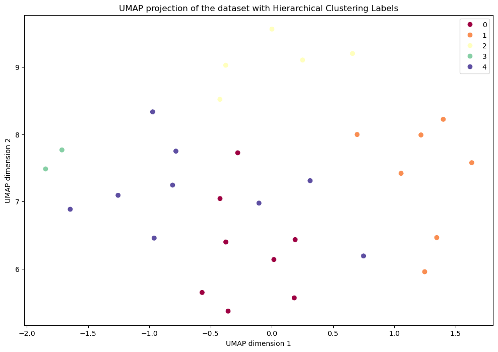

```python
import umap
import matplotlib.pyplot as plt
import seaborn as sns

# Initialize and fit UMAP
reducer = umap.UMAP(n_neighbors=15, min_dist=0.1, metric='euclidean', random_state=42)
embedding = reducer.fit_transform(UVstd)

# Plot the UMAP projection
plt.figure(figsize=(12, 8))
sns.scatterplot(x=embedding[:, 0], y=embedding[:, 1], hue=hierarchical_labels, palette="Spectral", legend='full', s=60)
plt.title('UMAP projection of the dataset with Hierarchical Clustering Labels')
plt.xlabel('UMAP dimension 1')
plt.ylabel('UMAP dimension 2')
plt.show()
```

*Cell Intentionally Blank*

## Submission

Make sure you have run all cells in your notebook in order before running the cell below, so that all images/graphs appear in the output. The cell below will generate a zip file for you to submit. **Please save before exporting!**

Download the zip file and submit to Gradescope.

```python
# Save your notebook first, then run this cell to export your submission.
grader.export(run_tests=True)
```